# Mise en oeuvre réseau de l’afficheur lumineux LED Moving Sign

Il est conseillé de lire ou de s’aider de ce document et de ses [cours réseaux](http://tvaira.free.fr/bts-sn/reseaux/cours/) avant de poursuive.

## Présentation

Le panneau lumineux est un afficheur extérieur à Leds 16x96 (Ambre, pitch 16). Il a été facturé 2550 euros HT par la société DVI SIGNS.

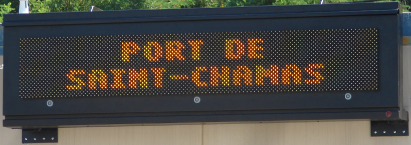

Site : [www.dvisigns.com](http://www.dvisigns.com/)

Les documentations sur ce panneau lumineux sont ici : doc/panneau-lumineux/

```
Lire le document sur l'installation du panneau lumineux et ses outils.
Vous devez avoir noté son adresse MAC pour continuer.
```

Lire le document sur l’installation de l’afficheur lumineux LED Moving Sign.

Le panneau lumineux possède une liaison **Ethernet** via un module [LTRX XPort](http://www.lantronix.com/products/xport/) de Lantronix. Ce module réalise un pont RS232-RS485/Ethernet.

```
Ici, l'adresse MAC du module LTRX XPort du panneau lumineux est 00:20:4A:BA:01:C7.
```

## Identifications des paramètres réseau sous Linux

```
Pour cette partie, vous allez avoir besoin d'un analyseur de protocoles.
Lancer wireshark en mode root.
```

```
$ gksudo wireshark &
```

Ou :

[figure not shown]

Vérifier si l’adresse MAC du panneau est présente dans votre cache ARP :

```
$ arp -v
Address                  HWtype  HWaddress           Flags Mask            Iface
```

Démarrer une capture **wireshark** sur votre interface réseau et filtrer les trames qui contiennent seulement l’adresse MAC du panneau :

1. Identifier l’adresse IP. Vous devez observer des **paquets ARP** émis périodiquement toutes les 180 s par le panneau :

[figure not shown]

```
Ici, l'adresse IP du panneau est 192.168.52.250.
```

*Remarque :* il est aussi possible d’activer un `ping` en *broadcast* avec l’option `-b`.

Si vous devez modifier cette adresse : consulter le document Assigner une adresse IP au panneau lumineux.

2. Tester la communication IP vers le panneau lumineux :

```
$ ping -c 1 192.168.52.250
PING 192.168.52.250 (192.168.52.250) 56(84) bytes of data.
64 bytes from 192.168.52.250: icmp_req=1 ttl=64 time=0.399 ms

--- 192.168.52.250 ping statistics ---
1 packets transmitted, 1 received, 0% packet loss, time 0ms
rtt min/avg/max/mdev = 0.399/0.399/0.399/0.000 ms
```

3. Identifier le port de communication. Scanner les ports ouverts sur le panneau lumineux :

```
$ nmap -A -T4 192.168.52.250

Starting Nmap 5.21 ( http://nmap.org ) at 2015-11-20 16:05 CET
Nmap scan report for 192.168.52.250
Host is up (0.0044s latency).
Not shown: 996 closed ports
PORT      STATE SERVICE VERSION
80/tcp    open  http    Lantronix XPort embedded ethernet http config
|_html-title: Site doesn't have a title (text/html).
9999/tcp  open  telnet  Lantronix XPort telnetd 6.6.0.2 080926 (MAC 00204ABA01C7)
10001/tcp open  unknown
30718/tcp open  unknown

Service detection performed. Please report any incorrect results at http://nmap.org/submit/ .
Nmap done: 1 IP address (1 host up) scanned in 43.78 seconds
```

Il y a 4 ports ouverts, le panneau lumineux exécute donc 4 serveurs :

- un serveur web (`http`) sur le port 80 pour la configuration
- un serveur `telnet` sur le port 9999 pour la configuration
- **un serveur sur le port 10001 pour piloter l’affichage**
- un serveur sur le port 30718 utilisé lors de l’assignation de l’adresse IP

```
Ici, le port de communication TCP à joindre est 10001.
```

## Analyse de protocoles sous Windows

```
Pour cette partie, vous allez avoir besoin d'un analyseur de protocoles.
Vérifier si wireshark est installé, sinon installez le.
```

Lien : www.wireshark.org/download.html

La communication avec le panneau lumineux repose sur un protocole constructeur **MovingSign**. Le protocole **MovingSign** intervient au niveau la couche Application du modèle DoD et utilise les protocoles TCP et IP pour les couches Transport et Réseau. Les échanges avec l’afficheur se feront donc via un client TCP.

```
Vous devez avoir identifié l'adresse IP et le numero de port du panneau lumineux avant de continuer.
```

On se limitera à l’étude de deux types de trames :

- les trames de commandes de contrôle
- les trames de commande d’écriture de texte

Les trames de commandes de contrôle sont utilisées pour modifier les paramètres du panneau (luminosité, horodatage, etc …) et pour l’initialiser après chaque allumage.

1. Exécuter le logiciel Multimedia led 2007.
2. Démarrer une capture **wireshark** sur votre interface réseau et filtrer les trames qui contiennent seulement l’adresse IP de votre panneau :
3. Créer un message et transférer le vers le panneau :

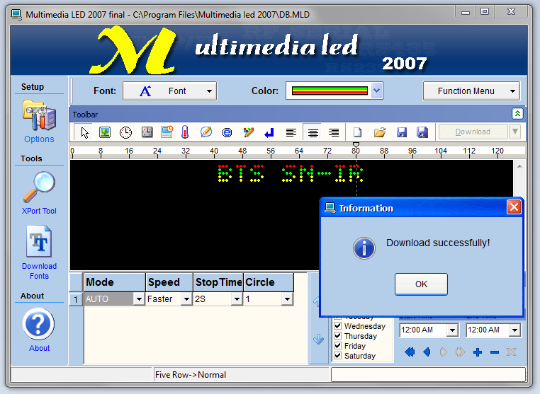

4. Vous devez capturer un échange TCP :

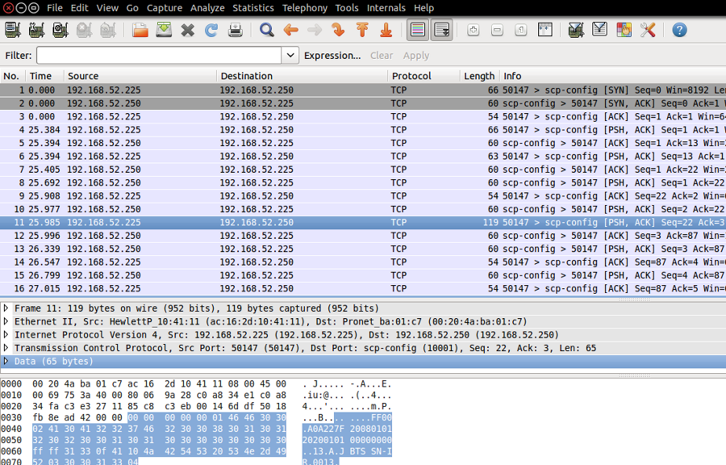

5. En utilisant les documentations sur le protocole MovingSign, décoder les données échangées lors de l’affichage d’un message afin d’en comprendre la structure.

Documentations : doc/panneau-lumineux/

- `Moving Sign Communication Protocol V2_1.pdf`
- `documentation-moving-sign.pdf`
- Fichier de capture `capture-led-sign.pcap` utilisable avec wireshark

Exemples de résultat attendu :

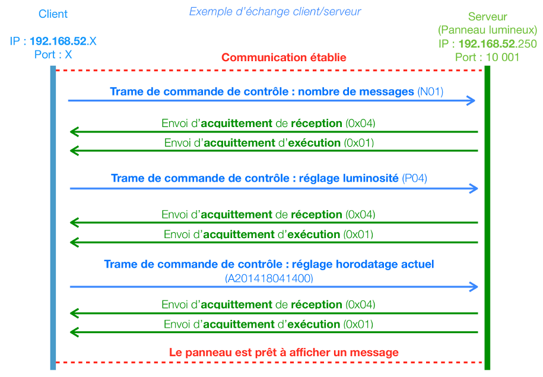

Diagramme d’échange

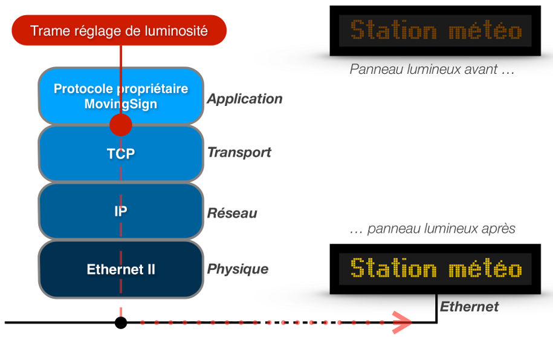

Modification de la luminosité

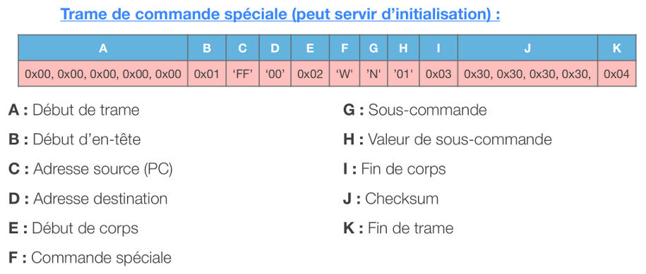

La trame d’initialisation

etc …

Retour au sommaire